# Assignment01_Part3_solution

## Part 3: Convolutional Neural Networks and Image Classification

[Total marks for this part: 50 points]

**This part of the asssignment is designed to access your knowledge and coding skill with Tensorflow as well as hands-on experience with training Convolutional Neural Network (CNN).**

**The dataset we use for this part is a small animal dataset consisting of $2000$ images of cats, dogs, fishes and lions, each of which has 500 images. You can download the dataset at [download here](https://drive.google.com/file/d/1t5b-pNMK5-uIK6wZIIHBluLY7tPK0JzV/view?usp=sharing) and then decompress to the folder the folder `datasets\Animals` for you in the assignment folder.**

**Your task is to build a CNN model using *TF 2.x* to classify these animals. You're provided with the module models.py, which you can find in the assignment folder, with some of the following classes:**

1. `AnimalsDatasetManager`: Support with loading and spliting the dataset into the train-val-test sets. It also help generate next batches for training. `AnimalsDatasetManager` will be passed to CNN model for training and testing.
2. `DefaultModel`: A base class for the CNN model.
3. `YourModel`: The class you'll need to implement to build the CNN model. It inherits some useful attributes and functions from the base class `DefaultModel`

Firstly, we need to run the following cells to load and preprocess the Animal dataset.

```python
%load_ext autoreload
%autoreload 2
```

```python
# This is needed so my kernel does not die.
import os
os.environ['KMP_DUPLICATE_LIB_OK']='True'
```

```python
import os
import matplotlib.pyplot as plt
plt.style.use('ggplot')
%matplotlib inline
import models
from models import SimplePreprocessor, AnimalsDatasetManager, DefaultModel
```

```python
import numpy as np
```

```python
def create_label_folder_dict(adir):
    sub_folders= [folder for folder in os.listdir(adir)
                  if os.path.isdir(os.path.join(adir, folder))]
    label_folder_dict= dict()
    for folder in sub_folders:
        item= {folder: os.path.abspath(os.path.join(adir, folder))}
        label_folder_dict.update(item)
    return label_folder_dict
```

```python
label_folder_dict= create_label_folder_dict("./datasets/Animals")
```

The below code helps to create a data manager that contains all relevant methods used to manage and process our experimental data.

```python
sp = SimplePreprocessor(width=32, height=32)
data_manager = AnimalsDatasetManager([sp])
data_manager.load(label_folder_dict, verbose=100)
data_manager.process_data_label()
data_manager.train_valid_test_split()
```

```
dogs 12500
Processed 100/500
Processed 200/500
Processed 300/500
Processed 400/500
Processed 500/500
fishes 500
Processed 100/500
Processed 200/500
Processed 300/500
Processed 400/500
Processed 500/500
cats 12500
Processed 100/500
Processed 200/500
Processed 300/500
Processed 400/500
Processed 500/500
lions 500
Processed 100/500
Processed 200/500
Processed 300/500
Processed 400/500
Processed 500/500
```

Note that the object `data_manager` has the attributes relating to *the training, validation, and testing sets* as shown belows. You can use them in training your developped models in the sequel.

```python
print(data_manager.X_train.shape, data_manager.y_train.shape)
print(data_manager.X_valid.shape, data_manager.y_valid.shape)
print(data_manager.X_test.shape, data_manager.y_test.shape)
print(data_manager.classes)
```

```
(1600, 32, 32, 3) (1600,)
(200, 32, 32, 3) (200,)
(200, 32, 32, 3) (200,)
['cats' 'dogs' 'fishes' 'lions']
```

We now run the **default model** built in the **models.py** file which serves as a basic baseline to start the investigation. Follow the following steps to realize how to run a model and know the built-in methods associated to a model developped in the DefaultModel class.

We first initialize a default model from the DefaultModel class. Basically, we can define the relevant parameters of training a model including `num_classes`, `optimizer`, `learning_rate`, `batch_size`, and `num_epochs`.

```python
network1 = DefaultModel(name='network1',
                       num_classes=len(data_manager.classes),
                       optimizer='sgd',
                       batch_size= 128,
                       num_epochs = 20,
                       learning_rate=0.5)
```

The method `build_cnn()` assists us in building your convolutional neural network. You can view the code (in the **models.py** file) of the model behind a default model to realize how simple it is. Additionally, the method `summary()` shows the architecture of a model.

```python
network1.build_cnn()
network1.summary()
```

```
Model: "sequential_1"
_________________________________________________________________
Layer (type)                 Output Shape              Param #
=================================================================
conv2d (Conv2D)              (None, 32, 32, 32)        896
_________________________________________________________________
conv2d_1 (Conv2D)            (None, 32, 32, 32)        9248
_________________________________________________________________
average_pooling2d (AveragePo (None, 16, 16, 32)        0
_________________________________________________________________
conv2d_2 (Conv2D)            (None, 16, 16, 64)        18496
_________________________________________________________________
conv2d_3 (Conv2D)            (None, 16, 16, 64)        36928
_________________________________________________________________
average_pooling2d_1 (Average (None, 8, 8, 64)          0
_________________________________________________________________
flatten (Flatten)            (None, 4096)              0
_________________________________________________________________
dense (Dense)                (None, 4)                 16388
=================================================================
Total params: 81,956
Trainable params: 81,956
Non-trainable params: 0
_________________________________________________________________
None
```

To train a model regarding to the datasets stored in `data_manager`, you can invoke the method `fit()` for which you can specify the batch size and number of epochs for your training.

```python
network1.fit(data_manager, batch_size = 64, num_epochs = 20)
```

```
Train on 1600 samples, validate on 200 samples
```

Here you can compute the accuracy of your trained model with respect to a separate testing set.

```python
network1.compute_accuracy(data_manager.X_test, data_manager.y_test)
```

```
0.245
```

Below shows how you can inspect the training progress.

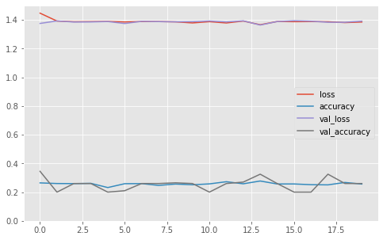

```python
network1.plot_progress()
```

You can use the method `predict()` to predict labels for data examples in a test set.

```python
network1.predict(data_manager.X_test[0:10])
```

```
array([3, 3, 3, 3, 3, 3, 3, 3, 3, 3])
```

Finally, the method `plot_prediction()` visualizes the predictions for a test set in which several images are chosen to show the predictions.

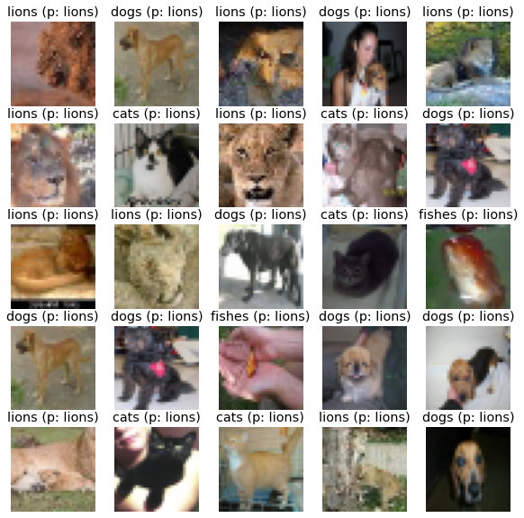

```python
network1.plot_prediction(data_manager.X_test, data_manager.y_test, data_manager.classes)
```

**Question 3.1.** **After running the above cells to train the default model and observe the learning curve. Report your observation (i.e. did the model learn well? if not, what is the problem? what would you do to improve it?). Write your answer below.**

[5 points]

*#Your answer and observation here*

The final test accuracy after training the default model is extremely low at 24.5%. Furthermore, from the prediction array and plot, we can see that the model predicts every single type of animal as a lion. From the progress plot, we can observe that the training loss and validation loss stayed constant throughout. Consequently, the training accuracy and validation accuracy stayed constant at about 20%-30% throughout. This is not desirable as the goal of training the model is to minimise the loss in order to make more accurate predictions. Thus, it is reasonable to conclude that the model did not learn well.

The failure of this model can be attributed to multiple things. We can see that the default model uses SGD as the optimizer, a batch size of 128, and learning rate of 0.5. However, using SGD as the optimizer might not be the best choice for this particular data set, perhaps a learning rate and batch size of 0.5 and 128, respectively, is too high. The architecture of this model might also not be fit for this particular data set.

To improve upon this model, we can attempt to tune the hyperparameters to more optimal values for this data set, including, but not limited to: choosing a different optimizer, choosing a different batch size, choosing a different learning rate, choosing a different number of filters, initialising the weights using techniques like He or Xavier weight initialization, changing the number of epochs, etc. We could also use a dynamic learning rate and perform early stopping to avoid overfitting to the training set so the model can generalise well to new, unseen data. Another possibility is to modify the architecture of the model by changing the number of layers, adding new types of layers and adding regularization in the layers.

**Question 3.2.** **Normally the first parameter to tune in Deep Learning is learning rate. In this question, you'll try running the default model with different learning rates (recommended in the list $[0.0001, 0.001, 0.005, 0.01]$) by entering the value in the cell below and run it. You should write your own code below for this learning rate tuning. Note that you can set the attribute `verbose` of the `DefaultModel` class to `False` for keeping the training silently without showing its details. Report the learning rates you tried along with the validation accuracy for each learning rate. What is the final learning rate that you'll use? Why?**

[5 points]

```python
# Tuning the learning rate
learning_rates = [0.0001, 0.0005, 0.001, 0.005, 0.01, 0.05, 0.1, 0.5]
best_acc = -np.inf

for lr in learning_rates:
    network2 = DefaultModel(name='network2',
                           num_classes=len(data_manager.classes),
                           optimizer='adam',
                           batch_size=128,
                           num_epochs=20,
                           learning_rate=lr,  # Set the appropriate learning rate
                           verbose=False)

    print("Training with learning rate = {}".format(lr))

    # Build the network and train.
    network2.build_cnn()
    network2.fit(data_manager, batch_size=64, num_epochs=20)

    # Get validation accuracy for this learning rate.
    valid_acc = network2.compute_accuracy(data_manager.X_valid, data_manager.y_valid)
    print("Learning Rate: {}, Validation Accuracy: {}".format(lr, valid_acc))

    if (valid_acc > best_acc):
        best_acc = valid_acc
        best_lr = lr
        best_model_lr = network2
```

```
Training with learning rate = 0.0001
Learning Rate: 0.0001, Validation Accuracy: 0.6100000143051147
Training with learning rate = 0.0005
Learning Rate: 0.0005, Validation Accuracy: 0.6800000071525574
Training with learning rate = 0.001
Learning Rate: 0.001, Validation Accuracy: 0.6700000166893005
Training with learning rate = 0.005
Learning Rate: 0.005, Validation Accuracy: 0.6399999856948853
Training with learning rate = 0.01
Learning Rate: 0.01, Validation Accuracy: 0.6499999761581421
Training with learning rate = 0.05
Learning Rate: 0.05, Validation Accuracy: 0.20000000298023224
Training with learning rate = 0.1
Learning Rate: 0.1, Validation Accuracy: 0.2800000011920929
Training with learning rate = 0.5
Learning Rate: 0.5, Validation Accuracy: 0.2800000011920929
```

```python
print('The best model is with learning rate = {}'.format(best_lr))
print('Evaluating the best model on the test set.')
best_model_lr.compute_accuracy(data_manager.X_test, data_manager.y_test)
```

```
The best model is with learning rate = 0.0005
Evaluating the best model on the test set.
```

```
0.685
```

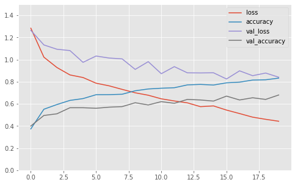

```python
best_model_lr.plot_progress()
```

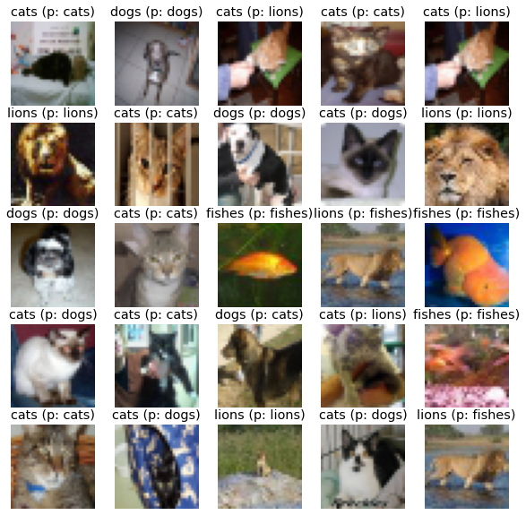

```python
best_model_lr.plot_prediction(data_manager.X_test, data_manager.y_test, data_manager.classes)
```

*Observation*

To tune the learning rate for the model, I tried out the following configurations: [0.0001, 0.0005, 0.001, 0.005, 0.01, 0.05, 0.1, 0.5]. The validation accuracies for each are [0.61, 0.68, 0.67, 0.64, 0.65, 0.2, 0.28, 0.28], respectively. Therefore, it makes sense to use 0.0005 for the final learning rate as it gives the highest validation accuracy of 68%. As we can see from the progress plot of the default model that uses a learning rate of 0.0005, the model does not seem to be overfitting yet as the validation loss is still decreasing. Thus, this is desirable as the model will still be able to generalise well to unseen data. Finally, this model gives a test accuracy of 68.5% which is a significant improvement considering the previous model yielded a test accuracy of 24.5%.

**For question 3.3 to 3.6, you'll need to write your own model in a way that makes it easy for you to experiment with different architectures as well as parameters. The goal is to be able to pass the parameters to initialize a new instance of `YourModel` to build different network architectures with different parameters. Below are descriptions of some parameters for `YourModel`, which you can find in function `__init__()` for the class `DefaultModel`:**

1. `num_blocks`: an integer specifying the number of blocks in our network. Each block has the pattern `[conv, batch norm, activation, conv, batch norm, activation, mean pool, dropout]`. All convolutional layers have filter size $(3, 3)$, strides $(1, 1)$ and 'SAME' padding, and all mean pool layers have strides $(2, 2)$ and 'SAME' padding. The network will consists of a few blocks before applying a linear layer to output the logits for the softmax layer.
2. `feature_maps`: the number of feature maps in the first block of the network. The number of feature_maps will double in each of the following block. To make it convenient for you, we already calculated the number of feature maps for each block for you in line $106$
3. `drop_rate`: the keep probability for dropout. Setting `drop_rate` to $0.0$ means not using dropout.
4. `batch_norm`: the batch normalization function is used or not. Setting `batch_norm` to `None` means not using batch normalization.

```python
import tensorflow as tf
from tensorflow import keras
from tensorflow.keras import layers, models
```

```python
tf.random.set_seed(30990971)
np.random.seed(30990971)
```

**Question 3.3.** **Write the code of the `YourModel` class here. Note that this class will inherit from the `DefaultModel` class. You'll only need to re-write the code for the `build_cnn` method for the `YourModel` class from the cell below which is inherited from the `DefaultModel` class.**

[5 points]

```python
class YourModel(DefaultModel):
    def __init__(self,
                 name='network1',
                 width=32, height=32, depth=3,
                 num_blocks=2,
                 feature_maps=32,
                 num_classes=4,
                 drop_rate=0.2,
                 batch_norm = None,
                 is_augmentation = False,
                 activation_func='relu',
                 optimizer='adam',
                 batch_size=10,
                 num_epochs= 20,
                 learning_rate=0.0001,
                 verbose= True):
        super(YourModel, self).__init__(name, width, height, depth, num_blocks, feature_maps, num_classes, drop_rate, batch_norm, is_augmentation,
                                        activation_func, optimizer, batch_size, num_epochs, learning_rate, verbose)

    def build_cnn(self):
        self.model = models.Sequential()   # Declare a sequential model.

        for i in range(self.num_blocks):
            if i == 0:
                self.model.add(layers.Conv2D(filters=self.feature_maps[i], kernel_size=(3,3), padding='same', input_shape=(32,32,3)))   # (1) Add first convolutional layer with input shape specified.
            else:
                self.model.add(layers.Conv2D(filters=self.feature_maps[i], kernel_size=(3,3), padding='same'))   # (1) The first convolutional layer in the block.

            if self.batch_norm:
                self.model.add(layers.BatchNormalization())   # (2) Add batch normalization layer if specified.

            self.model.add(layers.Activation(self.activation_func))   # (3) Add activation layer.

            self.model.add(layers.Conv2D(filters=self.feature_maps[i], kernel_size=(3,3), padding='same'))   # (4) Add convolutional layer.

            if self.batch_norm:
                self.model.add(layers.BatchNormalization())   # (5) Add batch normalization layer if specified.

            self.model.add(layers.Activation(self.activation_func))   # (6) Add activation layer.

            self.model.add(layers.AveragePooling2D(strides=(2,2), padding='same'))   # (7) Add average pooling layer.

            self.model.add(layers.Dropout(rate=self.drop_rate))   # (8) Add dropout layer.

        # Flattens the input to prepare for output layer.
        self.model.add(layers.Flatten())

        # Output layer with softmax activation function.
        self.model.add(layers.Dense(self.num_classes, activation='softmax'))

        # Compile model to define the loss function, optimizer and metrics.
        self.model.compile(optimizer=self.optimizer, loss='sparse_categorical_crossentropy', metrics=['accuracy'])
```

**Question 3.4.** **Once writing your own models, you should be able to use it to experiment with dropout or batch normalization. In this question, you'll use your model to finetune the dropout rate. Report the `drop_rate` rates you tried along with the validation accuracy for each rate (recomended range: 0.2 to 0.5). What is the final `drop_rate` rate that you'll use? Did dropout improve performance? Did it help reduce overfitting? Note that in this experiment, you should set `batch_norm` to `None`, meaning that we do not use the batch normalization.**

[5 points]

```python
# Tuning the drop rate.
drop_rates = [0.2, 0.25, 0.3, 0.35, 0.4, 0.45, 0.5]
best_acc = -np.inf

for dr in drop_rates:

    network3 = YourModel(name='network3',
                         feature_maps=32,
                         num_classes=len(data_manager.classes),
                         num_blocks=4,
                         drop_rate= dr,   # Set drop rate.
                         batch_norm=None,
                         optimizer='adam',
                         learning_rate= 0.001,
                         verbose=False)

    print("Training with drop rate = {}".format(dr))

    # Build and train the network.
    network3.build_cnn()
    network3.fit(data_manager, batch_size=64, num_epochs=20)

    # Get validation accuracy for this drop rate.
    valid_acc = network3.compute_accuracy(data_manager.X_valid, data_manager.y_valid)
    print("Drop Rate: {}, Validation Accuracy: {}".format(dr, valid_acc))

    # Save details for best model.
    if (valid_acc > best_acc):
        best_acc = valid_acc
        best_model_dr = network3
        best_dr = dr
```

```
Training with drop rate = 0.2
Drop Rate: 0.2, Validation Accuracy: 0.6449999809265137
Training with drop rate = 0.25
Drop Rate: 0.25, Validation Accuracy: 0.6850000023841858
Training with drop rate = 0.3
Drop Rate: 0.3, Validation Accuracy: 0.6499999761581421
Training with drop rate = 0.35
Drop Rate: 0.35, Validation Accuracy: 0.699999988079071
Training with drop rate = 0.4
Drop Rate: 0.4, Validation Accuracy: 0.6000000238418579
Training with drop rate = 0.45
Drop Rate: 0.45, Validation Accuracy: 0.6700000166893005
Training with drop rate = 0.5
Drop Rate: 0.5, Validation Accuracy: 0.6150000095367432
```

```python
print('The best model is with drop rate = {}'.format(best_dr))
print('Evaluating the best model on the test set')
best_model_dr.compute_accuracy(data_manager.X_test, data_manager.y_test)
```

```
The best model is with drop rate = 0.35
Evaluating the best model on the test set
```

```
0.65
```

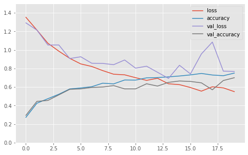

```python
best_model_dr.plot_progress()
```

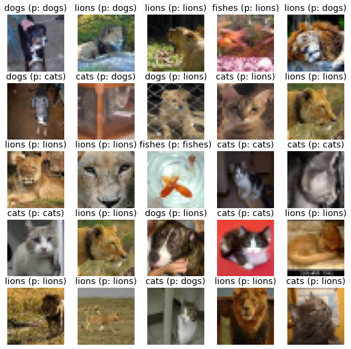

```python
best_model_dr.plot_prediction(data_manager.X_test, data_manager.y_test, data_manager.classes)
```

*Observations*

```python
drop_out_network = YourModel(name='network1',
                     feature_maps=32,
                     num_classes=len(data_manager.classes),
                     num_blocks=4,
                     drop_rate= 0.35, # enter your final dropout rate value here
                     batch_norm=None,
                     optimizer='adam',
                     learning_rate= 0.001)
drop_out_network.build_cnn()
drop_out_network.summary()
```

```
Model: "sequential_49"
_________________________________________________________________
Layer (type)                 Output Shape              Param #
=================================================================
conv2d_128 (Conv2D)          (None, 32, 32, 32)        896
_________________________________________________________________
activation_72 (Activation)   (None, 32, 32, 32)        0
_________________________________________________________________
conv2d_129 (Conv2D)          (None, 32, 32, 32)        9248
_________________________________________________________________
activation_73 (Activation)   (None, 32, 32, 32)        0
_________________________________________________________________
average_pooling2d_64 (Averag (None, 16, 16, 32)        0
_________________________________________________________________
dropout_36 (Dropout)         (None, 16, 16, 32)        0
_________________________________________________________________
conv2d_130 (Conv2D)          (None, 16, 16, 64)        18496
_________________________________________________________________
activation_74 (Activation)   (None, 16, 16, 64)        0
_________________________________________________________________
conv2d_131 (Conv2D)          (None, 16, 16, 64)        36928
_________________________________________________________________
activation_75 (Activation)   (None, 16, 16, 64)        0
_________________________________________________________________
average_pooling2d_65 (Averag (None, 8, 8, 64)          0
_________________________________________________________________
dropout_37 (Dropout)         (None, 8, 8, 64)          0
_________________________________________________________________
conv2d_132 (Conv2D)          (None, 8, 8, 128)         73856
_________________________________________________________________
activation_76 (Activation)   (None, 8, 8, 128)         0
_________________________________________________________________
conv2d_133 (Conv2D)          (None, 8, 8, 128)         147584
_________________________________________________________________
activation_77 (Activation)   (None, 8, 8, 128)         0
_________________________________________________________________
average_pooling2d_66 (Averag (None, 4, 4, 128)         0
_________________________________________________________________
dropout_38 (Dropout)         (None, 4, 4, 128)         0
_________________________________________________________________
conv2d_134 (Conv2D)          (None, 4, 4, 256)         295168
_________________________________________________________________
activation_78 (Activation)   (None, 4, 4, 256)         0
_________________________________________________________________
conv2d_135 (Conv2D)          (None, 4, 4, 256)         590080
_________________________________________________________________
activation_79 (Activation)   (None, 4, 4, 256)         0
_________________________________________________________________
average_pooling2d_67 (Averag (None, 2, 2, 256)         0
_________________________________________________________________
dropout_39 (Dropout)         (None, 2, 2, 256)         0
_________________________________________________________________
flatten_24 (Flatten)         (None, 1024)              0
_________________________________________________________________
dense_24 (Dense)             (None, 4)                 4100
=================================================================
Total params: 1,176,356
Trainable params: 1,176,356
Non-trainable params: 0
_________________________________________________________________
None
```

**Question 3.5.** **Now, let's try using batch normalization. What is the validation and test result? Does it improve the model? How does it compare to the model using dropout? To have a fair comparison, in this experiment, we set `drop_rate=0` to not use the dropout.**

[5 points]

```python
# Set up model.
network4 = YourModel(name='network4',
                     feature_maps=32,
                     num_classes=len(data_manager.classes),
                     num_blocks=4,
                     drop_rate= 0,
                     batch_norm=True, #do batch norm
                     optimizer='adam',
                     learning_rate= 0.001,
                     verbose=False)

print("Training with batch normalization.")

# Build and train model.
network4.build_cnn()
network4.fit(data_manager, batch_size=64, num_epochs=20)

# Get validation accuracy.
valid_acc = network4.compute_accuracy(data_manager.X_valid, data_manager.y_valid)
print('Validation Accuracy: {}'.format(dr, valid_acc))
```

```
Training with batch normalization.
Validation Accuracy: 0.5
```

```python
print("Evaluating the model with batch normalization on the test set.")
network4.compute_accuracy(data_manager.X_test, data_manager.y_test)
```

```
Evaluating the model with batch normalization on the test set.
```

```
0.71
```

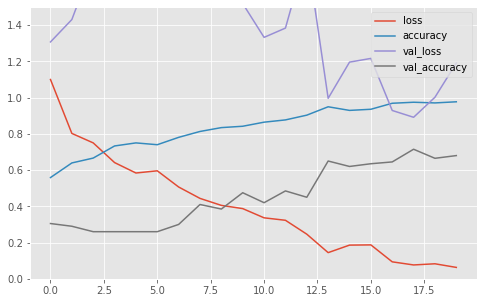

```python
network4.plot_progress()
```

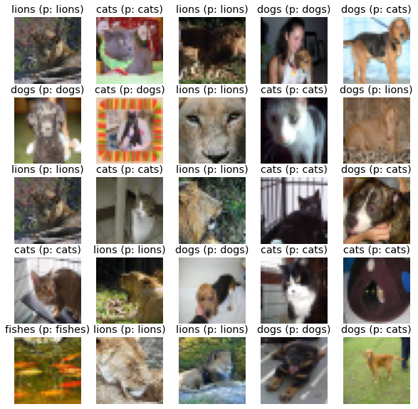

```python
network4.plot_prediction(data_manager.X_test, data_manager.y_test, data_manager.classes)
```

*Observations*

```python
batch_norm_network = YourModel(name='network4',
                     feature_maps=32,
                     num_classes=len(data_manager.classes),
                     num_blocks=4,
                     drop_rate= 0,
                     batch_norm=True, #do batch norm
                     optimizer='adam',
                     learning_rate= 0.001)
batch_norm_network.build_cnn()
batch_norm_network.summary()
```

```
Model: "sequential_53"
_________________________________________________________________
Layer (type)                 Output Shape              Param #
=================================================================
conv2d_144 (Conv2D)          (None, 32, 32, 32)        896
_________________________________________________________________
batch_normalization_8 (Batch (None, 32, 32, 32)        128
_________________________________________________________________
activation_88 (Activation)   (None, 32, 32, 32)        0
_________________________________________________________________
conv2d_145 (Conv2D)          (None, 32, 32, 32)        9248
_________________________________________________________________
batch_normalization_9 (Batch (None, 32, 32, 32)        128
_________________________________________________________________
activation_89 (Activation)   (None, 32, 32, 32)        0
_________________________________________________________________
average_pooling2d_72 (Averag (None, 16, 16, 32)        0
_________________________________________________________________
dropout_44 (Dropout)         (None, 16, 16, 32)        0
_________________________________________________________________
conv2d_146 (Conv2D)          (None, 16, 16, 64)        18496
_________________________________________________________________
batch_normalization_10 (Batc (None, 16, 16, 64)        256
_________________________________________________________________
activation_90 (Activation)   (None, 16, 16, 64)        0
_________________________________________________________________
conv2d_147 (Conv2D)          (None, 16, 16, 64)        36928
_________________________________________________________________
batch_normalization_11 (Batc (None, 16, 16, 64)        256
_________________________________________________________________
activation_91 (Activation)   (None, 16, 16, 64)        0
_________________________________________________________________
average_pooling2d_73 (Averag (None, 8, 8, 64)          0
_________________________________________________________________
dropout_45 (Dropout)         (None, 8, 8, 64)          0
_________________________________________________________________
conv2d_148 (Conv2D)          (None, 8, 8, 128)         73856
_________________________________________________________________
batch_normalization_12 (Batc (None, 8, 8, 128)         512
_________________________________________________________________
```

[output cut: 22 more lines]

```
activation_95 (Activation)   (None, 4, 4, 256)         0
_________________________________________________________________
average_pooling2d_75 (Averag (None, 2, 2, 256)         0
_________________________________________________________________
dropout_47 (Dropout)         (None, 2, 2, 256)         0
_________________________________________________________________
flatten_26 (Flatten)         (None, 1024)              0
_________________________________________________________________
dense_26 (Dense)             (None, 4)                 4100
=================================================================
Total params: 1,180,196
Trainable params: 1,178,276
Non-trainable params: 1,920
_________________________________________________________________
None
```

**Question 3.6.** **Finally, you should try to train the best model by trying different configurations for `num_blocks`, `feature_maps`, `optimizer`, `learning_rate`, `batch_size`, `keep_prob` and `batch_norm`. Briefly report the experiments that you try and your observation in the answer below. Also, run the cells below with the best configuration you found.**

[5 points]

*Discussion*

The cell below shows the different configurations of the number of blocks, number of feature maps, the optimizer, learning rate, batch sizes, dropout rates (which is equal to 1 - keep probability) and batch normalization hyperparameters that I have tried to tune in order to obtain the best model. Due to the heavy computational power involved with parameter tuning, I have decided to tune the parameters in a series of steps that was recommended by many of the online resources I have researched. Furthermore, in order to reduce overfitting, I modified the fit() function in models.py to stop the training early if the validation loss does not decrease consistently for 3 epochs. Also, I previously set a random seed for numpy and tensorflow in an attempt to reduce randomness.

For the fourth step, using the optimizer, learning rate, batch size and number of blocks from the previous step, I tuned the number of filters and found that starting with 16 filters was the most optimal, leading to a validation accuracy of 67.5%.

For the fifth and final step, using the previous hyperparameters I found before, I finally started to tune regularizers in the model, including the dropout rate and whether batch normalization is used or not. From the different configurations, I found that a dropout rate of 15% which is equal to a keep probability of 85%, and using batch normalization led to the best validation accuracy of 69.99%.

The final model uses the optimizer, Nadam, a learning rate of 0.0005, a batch size of 16, 2 blocks, 16 initial feature maps, with additional batch normalization layers and a dropout rate of 15% (keep probability of 85%). Training this model and testing on the test set gives a test accuracy of 74% which is the highest so far in comparison to the models tested in the previous sections.

```python
# Configurations to try for the different hyperparameters.
learning_rates = [0.0001, 0.0005, 0.001, 0.005, 0.01]
optimizers = ['adam', 'nadam', 'adagrad', 'rmsprop', 'adadelta', 'sgd']
# Increase batch size in powers of 2 to fit the memory requirements.
batch_sizes = [2**4, 2**5, 2**6, 2**7, 2**8, 2**9, 2**10]
num_blocks = [2, 3, 4, 5]
num_feature_maps = [8*(2**i) for i in range(5)]
drop_rate = [0.1, 0.15, 0.2, 0.25, 0.3, 0.35, 0.4, 0.45, 0.5]
batch_norms = (True, None)
```

```python
# (1) Tune learning rate and optimizer.
best_acc = -np.inf

for opt in optimizers:
    for lr in learning_rates:
        dnn1 = YourModel(name='dnn1',
                         num_classes=len(data_manager.classes),
                         optimizer=opt,   # Set optimizer.
                         learning_rate=lr,   # Set learning rate.
                         verbose=False)

        dnn1.build_cnn()
        dnn1.fit(data_manager, batch_size=64, num_epochs=20)

        valid_acc = dnn1.compute_accuracy(data_manager.X_valid, data_manager.y_valid)
        print("Optimizer: {}, Learning Rate: {}, Validation Accuracy: {}".format(opt, lr, valid_acc))

        if (valid_acc > best_acc):
            best_acc = valid_acc
            best_model = dnn1
            best_lr = lr
            best_opt = opt

print('The best model so far is with optimizer {} and learning rate: {}'.format(best_opt, best_lr))
```

```
Optimizer: adam, Learning Rate: 0.0001, Validation Accuracy: 0.574999988079071
Optimizer: adam, Learning Rate: 0.0005, Validation Accuracy: 0.6800000071525574
Optimizer: adam, Learning Rate: 0.001, Validation Accuracy: 0.6700000166893005
Optimizer: adam, Learning Rate: 0.005, Validation Accuracy: 0.6449999809265137
Optimizer: adam, Learning Rate: 0.01, Validation Accuracy: 0.20000000298023224
Optimizer: nadam, Learning Rate: 0.0001, Validation Accuracy: 0.6299999952316284
Optimizer: nadam, Learning Rate: 0.0005, Validation Accuracy: 0.6949999928474426
Optimizer: nadam, Learning Rate: 0.001, Validation Accuracy: 0.6600000262260437
Optimizer: nadam, Learning Rate: 0.005, Validation Accuracy: 0.6349999904632568
Optimizer: nadam, Learning Rate: 0.01, Validation Accuracy: 0.20000000298023224
Optimizer: adagrad, Learning Rate: 0.0001, Validation Accuracy: 0.2150000035762787
Optimizer: adagrad, Learning Rate: 0.0005, Validation Accuracy: 0.20000000298023224
Optimizer: adagrad, Learning Rate: 0.001, Validation Accuracy: 0.22499999403953552
Optimizer: adagrad, Learning Rate: 0.005, Validation Accuracy: 0.5699999928474426
Optimizer: adagrad, Learning Rate: 0.01, Validation Accuracy: 0.5799999833106995
Optimizer: rmsprop, Learning Rate: 0.0001, Validation Accuracy: 0.5649999976158142
Optimizer: rmsprop, Learning Rate: 0.0005, Validation Accuracy: 0.6299999952316284
Optimizer: rmsprop, Learning Rate: 0.001, Validation Accuracy: 0.6800000071525574
Optimizer: rmsprop, Learning Rate: 0.005, Validation Accuracy: 0.6499999761581421
Optimizer: rmsprop, Learning Rate: 0.01, Validation Accuracy: 0.5899999737739563
Optimizer: adadelta, Learning Rate: 0.0001, Validation Accuracy: 0.23999999463558197
Optimizer: adadelta, Learning Rate: 0.0005, Validation Accuracy: 0.2549999952316284
Optimizer: adadelta, Learning Rate: 0.001, Validation Accuracy: 0.3149999976158142
Optimizer: adadelta, Learning Rate: 0.005, Validation Accuracy: 0.3149999976158142
Optimizer: adadelta, Learning Rate: 0.01, Validation Accuracy: 0.36500000953674316
Optimizer: sgd, Learning Rate: 0.0001, Validation Accuracy: 0.20499999821186066
Optimizer: sgd, Learning Rate: 0.0005, Validation Accuracy: 0.25
Optimizer: sgd, Learning Rate: 0.001, Validation Accuracy: 0.20000000298023224
Optimizer: sgd, Learning Rate: 0.005, Validation Accuracy: 0.38499999046325684
Optimizer: sgd, Learning Rate: 0.01, Validation Accuracy: 0.5149999856948853
The best model so far is with optimizer nadam and learning rate: 0.0005
```

```python
# (2) Tune the batch size.
# Smaller batch size values give a learning process that converges quickly at the cost of noise in the training process.
# Large values give a learning process that converges slowly with accurate estimates of the error gradient.

best_acc = -np.inf

for batch_size in batch_sizes:
    dnn2 = YourModel(name='dnn2',
                     num_classes=len(data_manager.classes),
                     optimizer=best_opt,
                     learning_rate=best_lr,
                     batch_size=batch_size,    # Set the appropriate batch size.
                     verbose=False)

    dnn2.build_cnn()
    dnn2.fit(data_manager, num_epochs=20)

    valid_acc = dnn2.compute_accuracy(data_manager.X_valid, data_manager.y_valid)
    print("Optimizer: {}, Learning Rate: {}, Batch Size: {}, Validation Accuracy: {}".format(best_opt, best_lr, batch_size, valid_acc))

    if (valid_acc > best_acc):
        best_acc = valid_acc
        best_model = dnn2
        best_batch_size=batch_size

print('The best model so far is with optimizer {}, learning rate: {}, batch size: {}'.format(best_opt, best_lr, best_batch_size))
```

```
Optimizer: nadam, Learning Rate: 0.0005, Batch Size: 16, Validation Accuracy: 0.6800000071525574
Optimizer: nadam, Learning Rate: 0.0005, Batch Size: 32, Validation Accuracy: 0.6499999761581421
Optimizer: nadam, Learning Rate: 0.0005, Batch Size: 64, Validation Accuracy: 0.6150000095367432
Optimizer: nadam, Learning Rate: 0.0005, Batch Size: 128, Validation Accuracy: 0.5799999833106995
Optimizer: nadam, Learning Rate: 0.0005, Batch Size: 256, Validation Accuracy: 0.4950000047683716
Optimizer: nadam, Learning Rate: 0.0005, Batch Size: 512, Validation Accuracy: 0.47999998927116394
Optimizer: nadam, Learning Rate: 0.0005, Batch Size: 1024, Validation Accuracy: 0.5199999809265137
The best model so far is with optimizer nadam, learning rate: 0.0005, batch size: 16
```

```python
# (3) Tune the number of blocks.

best_acc = -np.inf

for num in num_blocks:
    dnn3 = YourModel(name='dnn3',
                     num_classes=len(data_manager.classes),
                     num_blocks=num,   # Set the number of blocks.
                     optimizer=best_opt,
                     batch_size=best_batch_size,
                     learning_rate=best_lr,
                     verbose=False)

    dnn3.build_cnn()
    dnn3.fit(data_manager)

    valid_acc = dnn3.compute_accuracy(data_manager.X_valid, data_manager.y_valid)
    print("Optimizer: {}, Learning Rate: {}, Batch Size: {}".format(best_opt, best_lr, best_batch_size))
    print("Number of Blocks: {}, Validation Accuracy: {}".format(num, valid_acc))

    if (valid_acc > best_acc):
        best_acc = valid_acc
        best_model = dnn3
        best_num_blocks = num

print('The best model so far is with optimizer {}, learning rate: {}, batch size: {}, number of blocks: {}, and validation accuracy: {}.'.format(best_opt, best_lr, best_batch_size, best_num_blocks, best_acc))
```

```
Optimizer: nadam, Learning Rate: 0.0005, Batch Size: 16
Number of Blocks: 2, Validation Accuracy: 0.6549999713897705
Optimizer: nadam, Learning Rate: 0.0005, Batch Size: 16
Number of Blocks: 3, Validation Accuracy: 0.6549999713897705
Optimizer: nadam, Learning Rate: 0.0005, Batch Size: 16
Number of Blocks: 4, Validation Accuracy: 0.6050000190734863
Optimizer: nadam, Learning Rate: 0.0005, Batch Size: 16
Number of Blocks: 5, Validation Accuracy: 0.6050000190734863
The best model so far is with optimizer nadam, learning rate: 0.0005, batch size: 16, number of blocks: 2, and validation accuracy: 0.6549999713897705.
```

```python
# (4) Tune the number of filters.

best_acc = -np.inf

for num_filters in num_feature_maps:

    dnn4 = YourModel(name='dnn4',
                     num_classes=len(data_manager.classes),
                     feature_maps=num_filters,   # Set the number of filters.
                     num_blocks=best_num_blocks,
                     optimizer=best_opt,
                     batch_size=best_batch_size,
                     learning_rate=best_lr,
                     verbose=False)

    dnn4.build_cnn()
    dnn4.fit(data_manager)

    valid_acc = dnn4.compute_accuracy(data_manager.X_valid, data_manager.y_valid)
    print("Optimizer: {}, Learning Rate: {}, Batch Size: {}".format(best_opt, best_lr, best_batch_size))
    print("Number of Blocks: {}, Number of Filters: {}, Validation Accuracy: {}".format(best_num_blocks, num_filters, valid_acc))

    if (valid_acc > best_acc):
        best_acc = valid_acc
        best_model = dnn4
        best_num_filters = num_filters

print('The best model so far is with optimizer {}, learning rate: {}, batch size: {}, number of blocks: {}, number of filters: {}, and validation accuracy: {}.'.format(best_opt, best_lr, best_batch_size, best_num_blocks, best_num_filters, best_acc))
```

```
Optimizer: nadam, Learning Rate: 0.0005, Batch Size: 16
Number of Blocks: 2, Number of Filters: 8, Validation Accuracy: 0.6499999761581421
Optimizer: nadam, Learning Rate: 0.0005, Batch Size: 16
Number of Blocks: 2, Number of Filters: 16, Validation Accuracy: 0.675000011920929
Optimizer: nadam, Learning Rate: 0.0005, Batch Size: 16
Number of Blocks: 2, Number of Filters: 32, Validation Accuracy: 0.6449999809265137
Optimizer: nadam, Learning Rate: 0.0005, Batch Size: 16
Number of Blocks: 2, Number of Filters: 64, Validation Accuracy: 0.675000011920929
Optimizer: nadam, Learning Rate: 0.0005, Batch Size: 16
Number of Blocks: 2, Number of Filters: 128, Validation Accuracy: 0.6700000166893005
The best model so far is with optimizer nadam, learning rate: 0.0005, batch size: 16, number of blocks: 2, number of filters: 16, and validation accuracy: 0.675000011920929.
```

```python
# (5) Tune the drop drate and batch normalization.

best_acc = -np.inf

for batch_norm in batch_norms:
    for dr in drop_rate:

        dnn5 = YourModel(name='dnn5',
                        num_classes=len(data_manager.classes),
                        feature_maps=best_num_filters,
                        num_blocks=best_num_blocks,
                        optimizer=best_opt,
                        batch_size=best_batch_size,
                        batch_norm=batch_norm,   # Set the batch normalization.
                        drop_rate=dr,   # Set the drop rate.
                        learning_rate=best_lr,
                        verbose=False)

        dnn5.build_cnn()
        dnn5.fit(data_manager)

        valid_acc = dnn5.compute_accuracy(data_manager.X_valid, data_manager.y_valid)
        print("Optimizer: {}, Learning Rate: {}, Batch Size: {}".format(best_opt, best_lr, best_batch_size))
        print("Number of Blocks: {}, Number of Filters: {}, Drop Rate: {}, Batch Norm: {}, Validation Accuracy: {}".format(best_num_blocks, best_num_filters, dr, batch_norm, valid_acc))

        if (valid_acc > best_acc):
            best_acc = valid_acc
            best_model = dnn5
            best_batch_norm = batch_norm
            best_dr = dr

print('The best model so far is with optimizer {}, learning rate: {}, batch size: {}, number of blocks: {}, number of filters: {}, drop rate: {}, batch normalization: {}, and validation accuracy: {}.'.format(best_opt, best_lr, best_batch_size, best_num_blocks, best_num_filters, best_dr, best_batch_norm, best_acc))
```

```
Optimizer: nadam, Learning Rate: 0.0005, Batch Size: 16
Number of Blocks: 2, Number of Filters: 16, Drop Rate: 0.1, Batch Norm: True, Validation Accuracy: 0.625
Optimizer: nadam, Learning Rate: 0.0005, Batch Size: 16
Number of Blocks: 2, Number of Filters: 16, Drop Rate: 0.15, Batch Norm: True, Validation Accuracy: 0.699999988079071
Optimizer: nadam, Learning Rate: 0.0005, Batch Size: 16
Number of Blocks: 2, Number of Filters: 16, Drop Rate: 0.2, Batch Norm: True, Validation Accuracy: 0.6800000071525574
Optimizer: nadam, Learning Rate: 0.0005, Batch Size: 16
Number of Blocks: 2, Number of Filters: 16, Drop Rate: 0.25, Batch Norm: True, Validation Accuracy: 0.6100000143051147
Optimizer: nadam, Learning Rate: 0.0005, Batch Size: 16
Number of Blocks: 2, Number of Filters: 16, Drop Rate: 0.3, Batch Norm: True, Validation Accuracy: 0.6800000071525574
Optimizer: nadam, Learning Rate: 0.0005, Batch Size: 16
Number of Blocks: 2, Number of Filters: 16, Drop Rate: 0.35, Batch Norm: True, Validation Accuracy: 0.6000000238418579
Optimizer: nadam, Learning Rate: 0.0005, Batch Size: 16
Number of Blocks: 2, Number of Filters: 16, Drop Rate: 0.4, Batch Norm: True, Validation Accuracy: 0.5699999928474426
Optimizer: nadam, Learning Rate: 0.0005, Batch Size: 16
Number of Blocks: 2, Number of Filters: 16, Drop Rate: 0.45, Batch Norm: True, Validation Accuracy: 0.5350000262260437
Optimizer: nadam, Learning Rate: 0.0005, Batch Size: 16
Number of Blocks: 2, Number of Filters: 16, Drop Rate: 0.5, Batch Norm: True, Validation Accuracy: 0.46000000834465027
Optimizer: nadam, Learning Rate: 0.0005, Batch Size: 16
Number of Blocks: 2, Number of Filters: 16, Drop Rate: 0.1, Batch Norm: None, Validation Accuracy: 0.6449999809265137
Optimizer: nadam, Learning Rate: 0.0005, Batch Size: 16
Number of Blocks: 2, Number of Filters: 16, Drop Rate: 0.15, Batch Norm: None, Validation Accuracy: 0.699999988079071
Optimizer: nadam, Learning Rate: 0.0005, Batch Size: 16
Number of Blocks: 2, Number of Filters: 16, Drop Rate: 0.2, Batch Norm: None, Validation Accuracy: 0.6600000262260437
Optimizer: nadam, Learning Rate: 0.0005, Batch Size: 16
Number of Blocks: 2, Number of Filters: 16, Drop Rate: 0.25, Batch Norm: None, Validation Accuracy: 0.6899999976158142
Optimizer: nadam, Learning Rate: 0.0005, Batch Size: 16
Number of Blocks: 2, Number of Filters: 16, Drop Rate: 0.3, Batch Norm: None, Validation Accuracy: 0.6549999713897705
Optimizer: nadam, Learning Rate: 0.0005, Batch Size: 16
Number of Blocks: 2, Number of Filters: 16, Drop Rate: 0.35, Batch Norm: None, Validation Accuracy: 0.6449999809265137
Optimizer: nadam, Learning Rate: 0.0005, Batch Size: 16
Number of Blocks: 2, Number of Filters: 16, Drop Rate: 0.4, Batch Norm: None, Validation Accuracy: 0.6800000071525574
Optimizer: nadam, Learning Rate: 0.0005, Batch Size: 16
Number of Blocks: 2, Number of Filters: 16, Drop Rate: 0.45, Batch Norm: None, Validation Accuracy: 0.6150000095367432
Optimizer: nadam, Learning Rate: 0.0005, Batch Size: 16
Number of Blocks: 2, Number of Filters: 16, Drop Rate: 0.5, Batch Norm: None, Validation Accuracy: 0.6499999761581421
The best model so far is with optimizer nadam, learning rate: 0.0005, batch size: 16, number of blocks: 2, number of filters: 16, drop rate: 0.15, batch normalization: True, and validation accuracy: 0.699999988079071.
```

```python
# Implementation of the best model found through trying different configurations below.
opt=best_opt
lr=best_lr
batch_size=best_batch_size
num_blocks=best_num_blocks
num_filters=best_num_filters
batch_norm=best_batch_norm
dr=best_dr

best_model = YourModel(name='best_model',
                       num_classes=len(data_manager.classes),
                       optimizer=opt,
                       learning_rate=lr,
                       batch_size=batch_size,
                       num_blocks=num_blocks,
                       feature_maps=num_filters,
                       batch_norm=batch_norm,
                       drop_rate=best_dr,
                       verbose=False)

print("Training with optimizer={}, learning rate={}, batch size={}, number of blocks={}, number of filters={}, batch normalization={}, drop rate={}".format(opt, lr, batch_size, num_blocks, num_filters, batch_norm, dr))

# Build and train the model.
best_model.build_cnn()
best_model.fit(data_manager)

# Get validation accuracy.
valid_acc = best_model.compute_accuracy(data_manager.X_valid, data_manager.y_valid)
print("Validation Accuracy: {}".format(valid_acc))
best_model_valid_acc = valid_acc
```

```
Training with optimizer=nadam, learning rate=0.0005, batch size=16, number of blocks=2, number of filters=16, batch normalization=True, drop rate=0.15
Validation Accuracy: 0.6700000166893005
```

```python
print("Evaluating the best model on the test set.")
best_model.compute_accuracy(data_manager.X_test, data_manager.y_test)
```

```
Evaluating the best model on the test set.
```

```
0.74
```

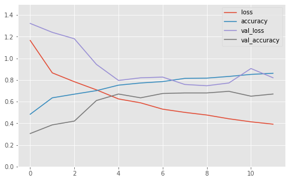

```python
best_model.plot_progress()
```

**Question 3.7.** **We now try to apply data augmentation to improve the performance. Extend the code of the class `YourModel` so that if the attribute `is_augmentation` is set to `True`, we apply the data augmentation.**

[5 points]

```python
from keras.preprocessing.image import ImageDataGenerator
```

```python
from keras.callbacks import EarlyStopping
```

Wtire your code in the cell below. Hint that you can rewrite the code of `fit` method to apply the data augmentation. In addition, you can copy the code of `build_cnn` method above to reuse here.

```python
class YourModel(DefaultModel):
    def __init__(self,
                 name='network1',
                 width=32, height=32, depth=3,
                 num_blocks=2,
                 feature_maps=32,
                 num_classes=4,
                 drop_rate=0.2,
                 batch_norm = None,
                 is_augmentation = False,
                 activation_func='relu',
                 optimizer='adam',
                 batch_size=10,
                 num_epochs= 20,
                 learning_rate=0.0001):
        super(YourModel, self).__init__(name, width, height, depth, num_blocks, feature_maps, num_classes, drop_rate, batch_norm, is_augmentation,
                                        activation_func, optimizer, batch_size, num_epochs, learning_rate)

    def build_cnn(self):
        self.model = models.Sequential()   # Declare a sequential model.

        for i in range(self.num_blocks):
            if i == 0:
                self.model.add(layers.Conv2D(filters=self.feature_maps[i], kernel_size=(3,3), padding='same', input_shape=(32,32,3)))   # (1) Add first convolutional layer with input shape specified.
            else:
                self.model.add(layers.Conv2D(filters=self.feature_maps[i], kernel_size=(3,3), padding='same'))   # (1) The first convolutional layer in the block.

            if self.batch_norm:
                self.model.add(layers.BatchNormalization())   # (2) Add batch normalization layer if specified.

            self.model.add(layers.Activation(self.activation_func))   # (3) Add activation layer.

            self.model.add(layers.Conv2D(filters=self.feature_maps[i], kernel_size=(3,3), padding='same'))   # (4) Add convolutional layer.

            if self.batch_norm:
                self.model.add(layers.BatchNormalization())   # (5) Add batch normalization layer if specified.

            self.model.add(layers.Activation(self.activation_func))   # (6) Add activation layer.

            self.model.add(layers.AveragePooling2D(strides=(2,2), padding='same'))   # (7) Add average pooling layer.

            self.model.add(layers.Dropout(rate=self.drop_rate))   # (8) Add dropout layer.

        # Flattens the input to prepare for output layer.
        self.model.add(layers.Flatten())

        # Output layer with softmax activation function.
        self.model.add(layers.Dense(self.num_classes, activation='softmax'))

        # Compile model to define the loss function, optimizer and metrics.
        self.model.compile(optimizer=self.optimizer, loss='sparse_categorical_crossentropy', metrics=['accuracy'])

    def fit(self, data_manager, batch_size=None, num_epochs=None):
        # Early stopping.
        early_checkpoint = EarlyStopping(patience=3, monitor='val_loss', mode='min')
        callbacks = [early_checkpoint]

        batch_size = self.batch_size if batch_size is None else batch_size
        num_epochs = self.num_epochs if num_epochs is None else num_epochs

        self.model.compile(optimizer=self.optimizer, loss='sparse_categorical_crossentropy', metrics=['accuracy'])

        # Apply data augmentation.
        if self.is_augmentation:
            # randomly rotate +/- 5 degrees
            # horizontally and vertically shifted by a factor of 2
            # sheared by 0.1
            # zoomed uniformly sampling in the range [0.9, 1.1]
            # randomly horizontally flipped
            aug = ImageDataGenerator(rotation_range=5, width_shift_range=0.1, height_shift_range=0.1, shear_range=0.1,
                                     zoom_range=0.1, horizontal_flip=True, fill_mode="nearest")
            self.history = self.model.fit_generator(aug.flow(x=data_manager.X_train, y=data_manager.y_train, batch_size=batch_size),
                                                    epochs=num_epochs, validation_data=(data_manager.X_valid, data_manager.y_valid),
                                                    callbacks=callbacks, verbose=self.verbose)
        else:
            self.history = self.model.fit(x=data_manager.X_train, y=data_manager.y_train, validation_data=(data_manager.X_valid, data_manager.y_valid),
                                          epochs=num_epochs, batch_size=batch_size, callbacks=callbacks, verbose=self.verbose)
```

**Question 3.8.** **Leverage the data augmentation with the best model you found before and try to observe if you can really boost the performance.**

[5 points]

*Observations*

```python
augmentation_network = YourModel(name='network5',
                     feature_maps=best_num_filters,
                     num_classes=len(data_manager.classes),
                     num_blocks=best_num_blocks,
                     drop_rate=best_dr,
                     batch_norm=best_batch_norm,
                     is_augmentation= True,   # Set data augmentation to true.
                     optimizer=best_opt,
                     learning_rate=best_lr)
augmentation_network.build_cnn()
augmentation_network.summary()
```

```
Model: "sequential_339"
_________________________________________________________________
Layer (type)                 Output Shape              Param #
=================================================================
conv2d_756 (Conv2D)          (None, 32, 32, 16)        448
_________________________________________________________________
batch_normalization_124 (Bat (None, 32, 32, 16)        64
_________________________________________________________________
activation_700 (Activation)  (None, 32, 32, 16)        0
_________________________________________________________________
conv2d_757 (Conv2D)          (None, 32, 32, 16)        2320
_________________________________________________________________
batch_normalization_125 (Bat (None, 32, 32, 16)        64
_________________________________________________________________
activation_701 (Activation)  (None, 32, 32, 16)        0
_________________________________________________________________
average_pooling2d_378 (Avera (None, 16, 16, 16)        0
_________________________________________________________________
dropout_350 (Dropout)        (None, 16, 16, 16)        0
_________________________________________________________________
conv2d_758 (Conv2D)          (None, 16, 16, 32)        4640
_________________________________________________________________
batch_normalization_126 (Bat (None, 16, 16, 32)        128
_________________________________________________________________
activation_702 (Activation)  (None, 16, 16, 32)        0
_________________________________________________________________
conv2d_759 (Conv2D)          (None, 16, 16, 32)        9248
_________________________________________________________________
batch_normalization_127 (Bat (None, 16, 16, 32)        128
_________________________________________________________________
activation_703 (Activation)  (None, 16, 16, 32)        0
_________________________________________________________________
average_pooling2d_379 (Avera (None, 8, 8, 32)          0
_________________________________________________________________
dropout_351 (Dropout)        (None, 8, 8, 32)          0
_________________________________________________________________
flatten_169 (Flatten)        (None, 2048)              0
_________________________________________________________________
dense_169 (Dense)            (None, 4)                 8196
=================================================================
Total params: 25,236
Trainable params: 25,044
Non-trainable params: 192
_________________________________________________________________
None
```

```python
print("Training the best model with data augmentation.")
augmentation_network.fit(data_manager)

# Get validation accuracy.
valid_acc = augmentation_network.compute_accuracy(data_manager.X_valid, data_manager.y_valid)
print("Validation accuracy: {}".format(valid_acc))

if valid_acc > best_model_valid_acc:
    best_model_valid_acc = valid_acc
    best_augmentation = True
else:
    best_augmentation = False
```

```
Training the best model with data augmentation.
WARNING:tensorflow:sample_weight modes were coerced from
  ...
    to
  ['...']
Train for 160 steps, validate on 200 samples
Validation accuracy: 0.6899999976158142
```

```python
print("Evaluating the best model on the test set.")
augmentation_network.compute_accuracy(data_manager.X_test, data_manager.y_test)
```

```
Evaluating the best model on the test set.
```

```
0.72
```

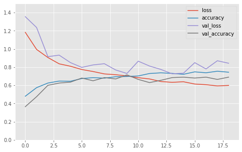

```python
augmentation_network.plot_progress()
```

**Question 3.9.** **Attack your best obtained model with PGD and FGSM attacks with $\epsilon= 0.0313, k=20, \eta= 0.005$ on the testing set. Write the code for the attacks and report the robust accuracies. Also choose a random set of 20 clean images in the testing set and visualize the original and attacked images.**

[5 points]

*Observations*

```python
from sklearn.metrics import accuracy_score
import cleverhans
from cleverhans.future.tf2.attacks import projected_gradient_descent, fast_gradient_method, momentum_iterative_method
```

```python
# Fit the best obtained model.
best_model = YourModel(name='best_model',
                       num_classes=len(data_manager.classes),
                       optimizer=best_opt,
                       learning_rate=best_lr,
                       batch_size=best_batch_size,
                       num_blocks=best_num_blocks,
                       feature_maps=best_num_filters,
                       batch_norm=best_batch_norm,
                       drop_rate=best_dr,
                       is_augmentation=best_augmentation)

# Build and train the model.
best_model.build_cnn()
best_model.fit(data_manager)

# Get validation accuracy.
valid_acc = best_model.compute_accuracy(data_manager.X_valid, data_manager.y_valid)
print("Validation accuracy: {}".format(valid_acc))
```

```
WARNING:tensorflow:sample_weight modes were coerced from
  ...
    to
  ['...']
Train for 100 steps, validate on 200 samples
Validation accuracy: 0.6399999856948853
```

```python
best_model.summary()
```

```
Model: "sequential_357"
_________________________________________________________________
Layer (type)                 Output Shape              Param #
=================================================================
conv2d_792 (Conv2D)          (None, 32, 32, 16)        448
_________________________________________________________________
batch_normalization_160 (Bat (None, 32, 32, 16)        64
_________________________________________________________________
activation_736 (Activation)  (None, 32, 32, 16)        0
_________________________________________________________________
conv2d_793 (Conv2D)          (None, 32, 32, 16)        2320
_________________________________________________________________
batch_normalization_161 (Bat (None, 32, 32, 16)        64
_________________________________________________________________
activation_737 (Activation)  (None, 32, 32, 16)        0
_________________________________________________________________
average_pooling2d_396 (Avera (None, 16, 16, 16)        0
_________________________________________________________________
dropout_368 (Dropout)        (None, 16, 16, 16)        0
_________________________________________________________________
conv2d_794 (Conv2D)          (None, 16, 16, 32)        4640
_________________________________________________________________
batch_normalization_162 (Bat (None, 16, 16, 32)        128
_________________________________________________________________
activation_738 (Activation)  (None, 16, 16, 32)        0
_________________________________________________________________
conv2d_795 (Conv2D)          (None, 16, 16, 32)        9248
_________________________________________________________________
batch_normalization_163 (Bat (None, 16, 16, 32)        128
_________________________________________________________________
activation_739 (Activation)  (None, 16, 16, 32)        0
_________________________________________________________________
average_pooling2d_397 (Avera (None, 8, 8, 32)          0
_________________________________________________________________
dropout_369 (Dropout)        (None, 8, 8, 32)          0
_________________________________________________________________
flatten_178 (Flatten)        (None, 2048)              0
_________________________________________________________________
dense_178 (Dense)            (None, 4)                 8196
=================================================================
Total params: 25,236
Trainable params: 25,044
Non-trainable params: 192
_________________________________________________________________
None
```

```python
# Get list of layer names.
for (i, layer) in enumerate(best_model.model.layers):
    print("{}\t{}\t{}".format(i, layer.__class__.__name__, layer.name))
```

```
0	Conv2D	conv2d_792
1	BatchNormalization	batch_normalization_160
2	Activation	activation_736
3	Conv2D	conv2d_793
4	BatchNormalization	batch_normalization_161
5	Activation	activation_737
6	AveragePooling2D	average_pooling2d_396
7	Dropout	dropout_368
8	Conv2D	conv2d_794
9	BatchNormalization	batch_normalization_162
10	Activation	activation_738
11	Conv2D	conv2d_795
12	BatchNormalization	batch_normalization_163
13	Activation	activation_739
14	AveragePooling2D	average_pooling2d_397
15	Dropout	dropout_369
16	Flatten	flatten_178
17	Dense	dense_178
```

```python
# Get best model with output logits as required by cleverhans.
flatten_layer = best_model.model.get_layer('flatten_178')
flatten_hidden = flatten_layer.output
output_layer = best_model.model.get_layer('dense_178')
output_weight = output_layer.weights[0]
print(flatten_hidden.shape, output_weight.shape)
output_logits = tf.matmul(flatten_hidden, output_weight)
print(output_logits.shape)
best_model_logits = tf.keras.Model(best_model.model.input, output_logits)
```

```
(None, 2048) (2048, 4)
(None, 4)
```

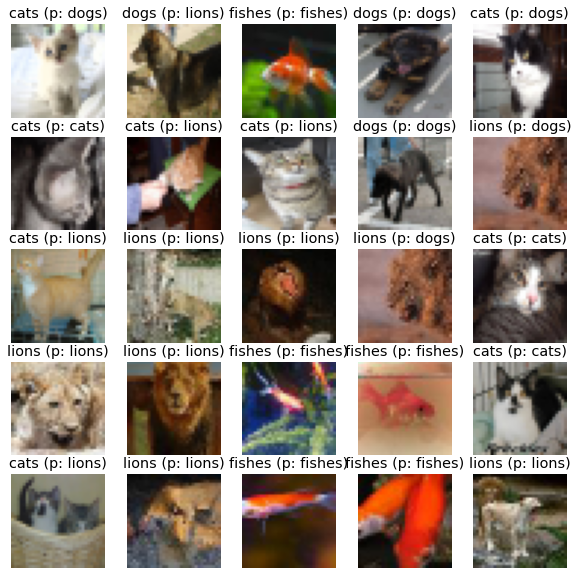

```python
preds = best_model.predict(data_manager.X_test)
best_model.plot_prediction(data_manager.X_test, data_manager.y_test, data_manager.classes)
```

```python
best_model.compute_accuracy(data_manager.X_test, data_manager.y_test)
```

```
0.665
```

```python
# Attack with Projected Gradient Descent (PGD).

eps = 0.0313   # epsilon (dictates the 'strength' of the distortion created)
eps_iter = 0.005  # eps_iter
k = 20   # nb_iter: 20 steps

# Project noise into images.
x_pgd = projected_gradient_descent(best_model_logits, x=data_manager.X_test, eps=eps, eps_iter=eps_iter, nb_iter=k, norm=np.inf)
pgd_pred = best_model.predict(x_pgd)
```

```python
# Evaluate the accuracy on test set.
best_model.compute_accuracy(x_pgd, data_manager.y_test)
```

```
0.405
```

```python
# Attack with Fast Gradient Method (FGD).
x_fgd = fast_gradient_method(best_model_logits, data_manager.X_test, eps, np.inf)
fgd_pred = best_model.predict(x_fgd)
```

```python
# Evaluate the accuracy on the test set.
best_model.compute_accuracy(x_fgd, data_manager.y_test)
```

```
0.495
```

[output not shown]

[output cut: 11 more lines]

[output not shown]

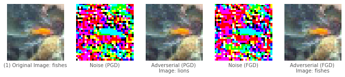

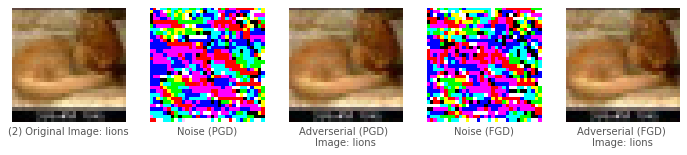

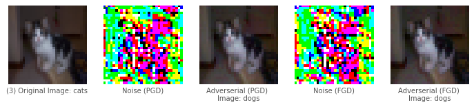

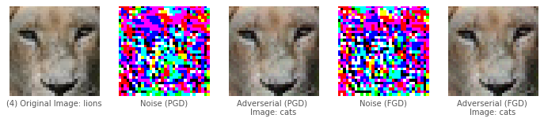

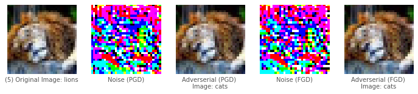

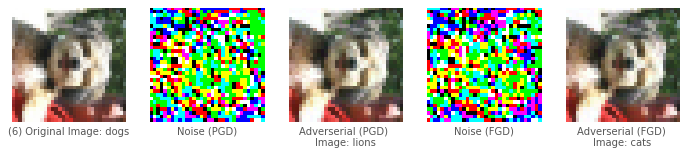

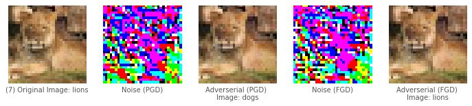

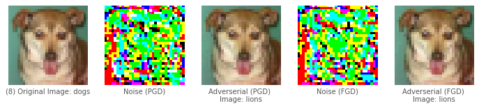

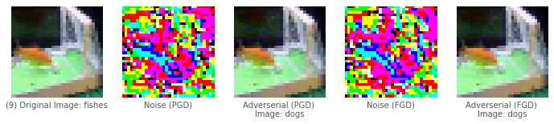

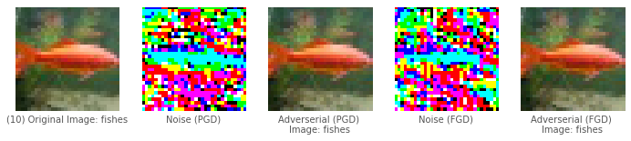

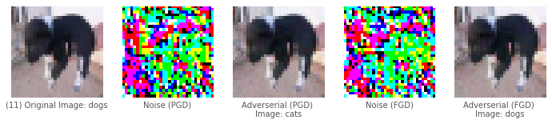

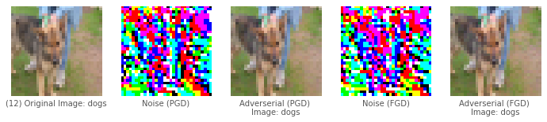

[8 more figures not shown]

```python
# Visualise original and attacked images from random set of 20 clean images in the testing set.

idx = np.random.choice(200, 20)   # Choose random 20 out of 200 images from test set.
count = 1

for image_id in idx:
    img_pgd = (x_pgd[image_id] + 1.0) / 2
    img_fgd = (x_fgd[image_id] + 1.0) / 2
    img = (data_manager.X_test[image_id] + 1) / 2
    noise_pgd = (img_pgd - img)*255
    noise_fgd = (img_fgd - img)*255
    fig = plt.figure(figsize=(12, 12))

    for i in range(5):
        if i == 0:
            shown_img = img
            shown_label = '({}) Original Image: {}'.format(count, data_manager.classes[data_manager.y_test[image_id]])
        elif i == 1:
            shown_img = noise_pgd
            shown_label = 'Noise (PGD)'
        elif i == 2:
            shown_img = img_pgd
            shown_label = 'Adverserial (PGD) \nImage: {}'.format(data_manager.classes[pgd_pred[image_id]])
        elif i == 3:
            shown_img = noise_fgd
            shown_label = 'Noise (FGD)'
        elif i == 4:
            shown_img = img_fgd
            shown_label = 'Adverserial (FGD) \nImage: {}'.format(data_manager.classes[fgd_pred[image_id]])

        plt.subplot(1, 5, i+1)
        plt.imshow(shown_img)
        plt.xlabel(shown_label, fontsize=10)
        plt.xticks([])
        plt.yticks([])
        plt.grid(False)

    count += 1
```

**Question 3.10.** **Train a robust model using adversarial training with PGD $\{\epsilon= 0.0313, k=10, \eta= 0.005\}$. Write the code for the adversarial training and report the robust accuracies. After finishing the training, you need to store your best robust model in the folder `./models` and load the model to evaluate the robust accuracies for PGD and FGSM attacks with $\epsilon= 0.0313, k=20, \eta= 0.005$ on the testing set.**

[5 points]

*Observations*

```python
# Use best_model_logits (a model which outputs logits) that we have defined in the previous section.
best_model_defence = best_model_logits
```

```python
epochs = 20   # Number of epochs
optimizer = tf.optimizers.Nadam(learning_rate=0.0005)   # Best optimizer as found in previous section.
loss_obj = tf.losses.SparseCategoricalCrossentropy(from_logits=True)

# Metrics to track the different accuracies.
train_loss = tf.metrics.Mean(name='train_loss')
test_acc_clean = tf.metrics.SparseCategoricalAccuracy()
test_acc_pgd = tf.metrics.SparseCategoricalAccuracy()
```

```python
def train_step_adv(x, x_adv, y):
    with tf.GradientTape() as tape:
        predictions = best_model_defence(x)
        predictions_adv = best_model_defence(x_adv)
        loss = (loss_obj(y, predictions) + loss_obj(y, predictions_adv))/2
        gradients = tape.gradient(loss, best_model_defence.trainable_variables)
        optimizer.apply_gradients(zip(gradients, best_model_defence.trainable_variables))
```

```python
eps = 0.0313   # epsilon (dictates the 'strength' of the distortion created)
eps_iter = 0.005  # eps_iter
k = 10   # nb_iter: 10 steps
```

```python
for epoch in range(epochs):
    # keras like display of progress
    progress_bar_train = tf.keras.utils.Progbar(1600, verbose=1)
    for _ in range(len(data_manager.X_train)//best_batch_size):
        (x, y) = data_manager.next_batch(batch_size=best_batch_size)
        # Replace clean example with adverserial example by 10-steps projected_gradient_descent for adversarial training.
        x_adv = projected_gradient_descent(best_model_defence, x, eps, eps_iter, k, np.inf)
        train_step_adv(x, x_adv, y)
        y_pred = best_model_defence(x)
        test_acc_clean(y, y_pred)
        progress_bar_train.add(x.shape[0], values=[('loss', train_loss.result()), ("acc (%)", test_acc_clean.result() * 100)])
```

```python
# Save model
model_path = "./models/best_model_defence.h5"
best_model_defence.save(model_path)
```

```python
# Load model
loaded_model = tf.keras.models.load_model("./models/best_model_defence.h5")
```

```
WARNING:tensorflow:No training configuration found in save file: the model was *not* compiled. Compile it manually.
```

```python
# Evaluating the robust accuracies for PGD attack.

x_pgd_adv = projected_gradient_descent(loaded_model, data_manager.X_test, eps, eps_iter, k, np.inf)
y_pgd_adv = np.argmax(loaded_model(x_pgd_adv).numpy(), 1)

y_adv = y_pgd_adv.tolist()
y_true = data_manager.y_test.tolist()
```

```python
test_pgd_adv_acc = accuracy_score(y_true, y_adv)
print("Test Adversarial (PGD) Accuracy: {}".format(test_pgd_adv_acc))
```

```
Test Adversarial (PGD) Accuracy: 0.595
```

```python
# Evaluating the robust accuracies for FGD attack.

x_fgd_adv = fast_gradient_method(loaded_model, data_manager.X_test, eps, np.inf)
y_fgd_adv = np.argmax(loaded_model(x_fgd_adv).numpy(), 1)

y_adv = y_fgd_adv.tolist()
y_true = data_manager.y_test.tolist()
```

```python
test_fgd_adv_acc = accuracy_score(y_true, y_adv)
print("Test Adversarial (FGD) Accuracy: {}".format(test_fgd_adv_acc))
```

```
Test Adversarial (FGD) Accuracy: 0.625
```

END OF ASSIGNMENT